# Relatório de Análises Estatísticas: Violência e a violência dentro do ambiente educacional

Beatriz Nascimento, Maria Luiza Birra e Tayná Mendes

Universidade Federal do Estado do Rio de Janeiro - UNIRIO

Centro de Ciências Exatas e Tecnologia - CCET

Escola de Matemática - EM

Departamento de Matemática e Estatística - DME

Disciplina: Estatística aplicadas às Ciências Sociais

Relatório de Análises Estatísticas

=======================

# “Violência e a violência dentro do ambiente educacional”

## Professor: Steven Dutt-Ross

## Curso: Administração Pública

## Aluno: Beatriz Nascimento, Maria Luiza Birra e Tayná Mendes

## Turma: 2017.2

## 1. INTRODUÇÃO

> Um estudante de 12 anos morre vítima de uma surra dada por colegas em Belém.

> Adolescente é baleado na frente de escola durante tentativa de homicídio em Vitória.

> Guerra do tráfico fecha escolas no Rio de Janeiro.

São manchetes como essas que vemos recorrentemente, e a cada dia com mais frequência. Influenciadas pela presente realidade, buscamos descobrir com o presente trabalho se os altos indícios de violência tem induzido a violência dentro do ambiente escolar. Nos ateremos ao chamado bullying - ato agressivo sistemático, envolvendo ameaça, intimidação ou coesão, praticado contra alguém, por um indivíduo ou um grupo de pessoas. (dicionário Michaelis) -, e ao seu primeiro estágio, a ação verbal.

## 2. OBJETIVO PRINCIPAL

### O objetivo principal é analisar, com o apoio de ferramentas e modelos estatísticos, os fatores inseridos na violência, e se interferem e contribuem para as ocorrências do bullying verbal.

## a. OBJETIVOS ESPECÍFICOS

### Os objetivos específicos são comprovar se as hipóteses traçadas através do banco de dados se confirmam ou não. As hipóteses são:

## a) Há variância na violência entre as regiões?

## b) Há correlação entre a taxa de praticantes de Bullying com Tx de Homicídios?

## c) Há correlação entre a taxa de praticantes de Bullying com Tx de Latrocínios?

#### d) Há correlação entre a taxa de praticantes de Bullying com Tx de Lesão?

#### e) Há correlação entre a taxa de praticantes de Bullying com Tx de Crimes Violentos?

## 3. METODOLOGIA

### Utilizando o programa R e as suas interfaces R Commander e R Console, o trabalho é constituído por gráficos, mapa e testes de hipóteses. Os gráficos utilizados são: o Boxplot, este reunindo medidas de posição (mediana, intervalo inter-quartil, máximo e mínimo) e o Histograma, para final visualização do tipo de distribuição. Os testes de hipóteses se constituem de teste de normalidade no primeiro momento para todas as variáveis, para que se saiba a natureza da distribuição - normal ou não - e posteriormente é feito o teste de correlação, primeiramente de interação de variáveis qualitativas e quantitativas, denominado Anova, e subsequentemente para hipóteses com duas variáveis quantitativas, utilizando o método de Pearson quando as distribuições das duas forem normais e o método de Spearman quando uma das variáveis ou as duas não eram normais. Para haver uma conclusão é necessário analisar o p-valor encontrado em cada teste.

### A base de dados tem o número de observações igual a 27 (abrangendo os 26 estados do Brasil e o distrito federal) e 14 variáveis (Tabela 1).

### Tabela 1 Descrição dos Dados

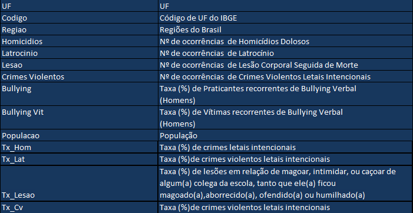

### 3.1 CRITÉRIOS DO TESTE DE HIPÓTESES

#### Os critérios estabelecidos para a realização do teste de hipóteses foram os seguintes:

#### No teste de normalidade:

#### H0: a distribuição é normal

#### H1: a distribuição não é normal

#### O alfa foi de 0,05, que é o mais utilizado nas ciências sociais.

#### pv<=alpha rej H0

#### pv>alpha não rej H0

#### Nos testes de correlação:

#### Qualitativa x Quantitativa

#### H0: µVARIÁVEL1 = µVARIÁVEL2 = µVARIÁVEL3 = µVARIÁVEL4= µVARIÁVEL5

#### H1: Pelo menos uma média diferente

#### pv<= alpha rej H0

#### pv>alpha não rej H0

#### Quantitativa x Quantitativa

#### H0: p=0 -> não se correlacionam (são independentes)

#### H1:p diferente de 0 -> não são independentes.

#### A regra de decisão continuou sendo o alfa de 0,05

#### p-valor<=alpha - rejeito a H0

#### p-valor>alpha - não rejeito H0

## 4. ANÁLISES GRÁFICAS

```r
> final <- readXL("E:/finaL/BASE.xlsX", rownames=FALSE, header=TRUE, na="", sheet="Dados", stringsAsFactors=TRUE)
```

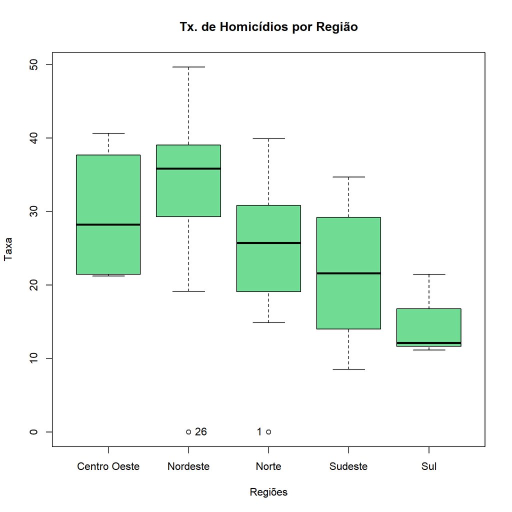

```
[1] "26" "1"
```

```r
> Boxplot(Tx_Hom~Regiao, data=final, id.method="y", xlab="Regiões", ylab="Taxa",
+   col=c("#70DB93"),
+   main="Tx. de Homicídios por Região")
```

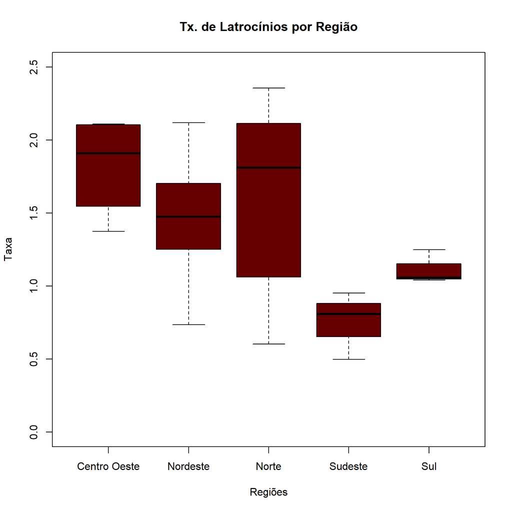

```r
> Boxplot(Tx_Lat~Regiao, data=final, id.method="y", xlab="Regiões", ylab="Taxa",
+   ylim=c(0,2.5), col=c("#660000"),
+   main="Tx. de Latrocínios por Região")
```

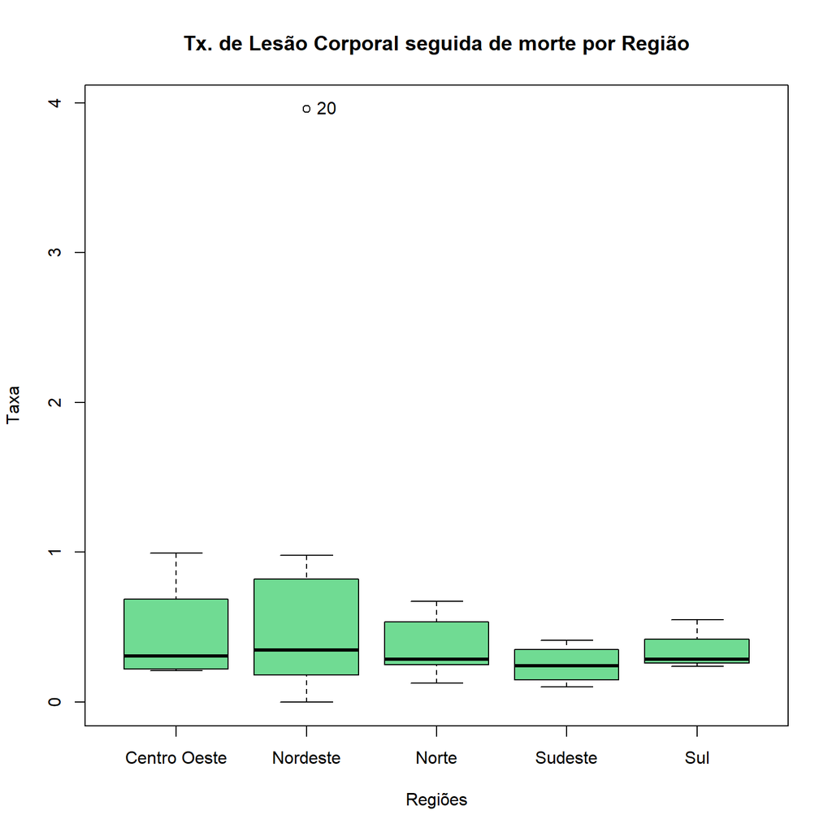

```
[1] "20"
```

```r
> Boxplot(Tx_Lesao~Regiao, data=final, id.method="y", xlab="Regiões", ylab="Taxa",
+   col=c("#70DB93"),
+   main="Tx. de Lesão Corporal seguida de morte por Região")
```

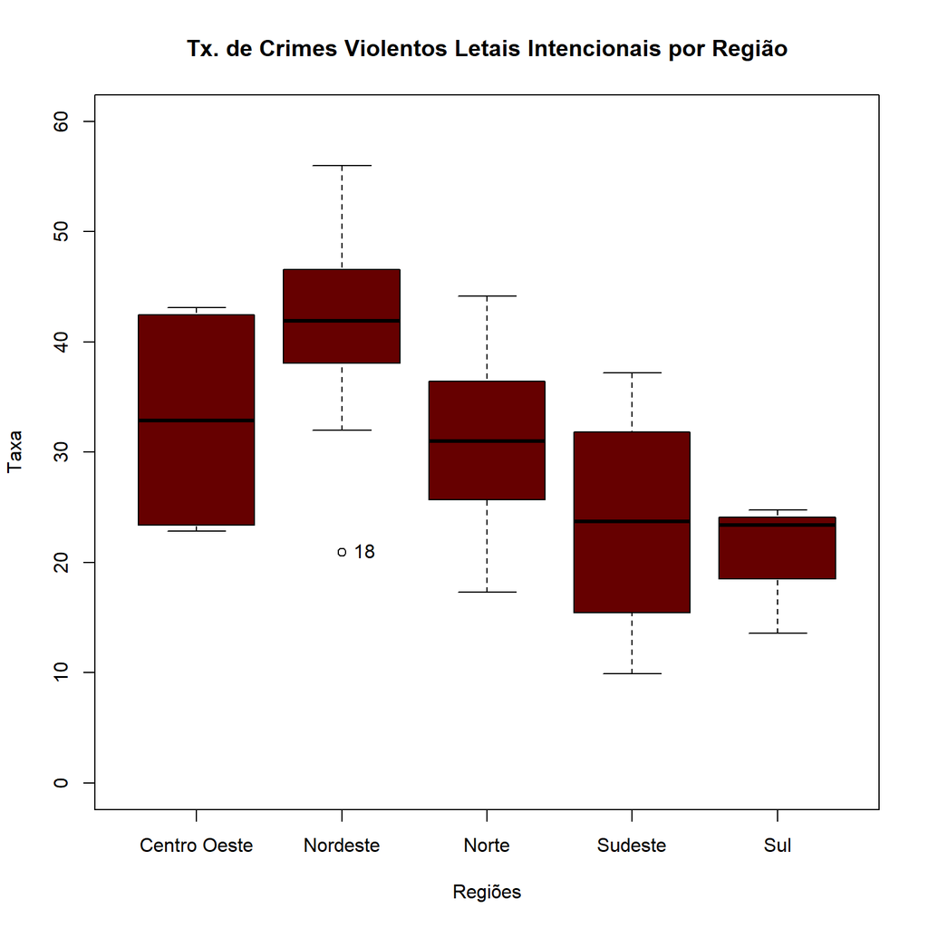

```
[1] "18"
```

```r
> Boxplot(Tx_Cv~Regiao, data=final, id.method="y", xlab="Regiões", ylab="Taxa",
+   ylim=c(0,60),col=c("#660000"),
+   main="Tx. de Crimes Violentos Letais Intencionais por Região")
```

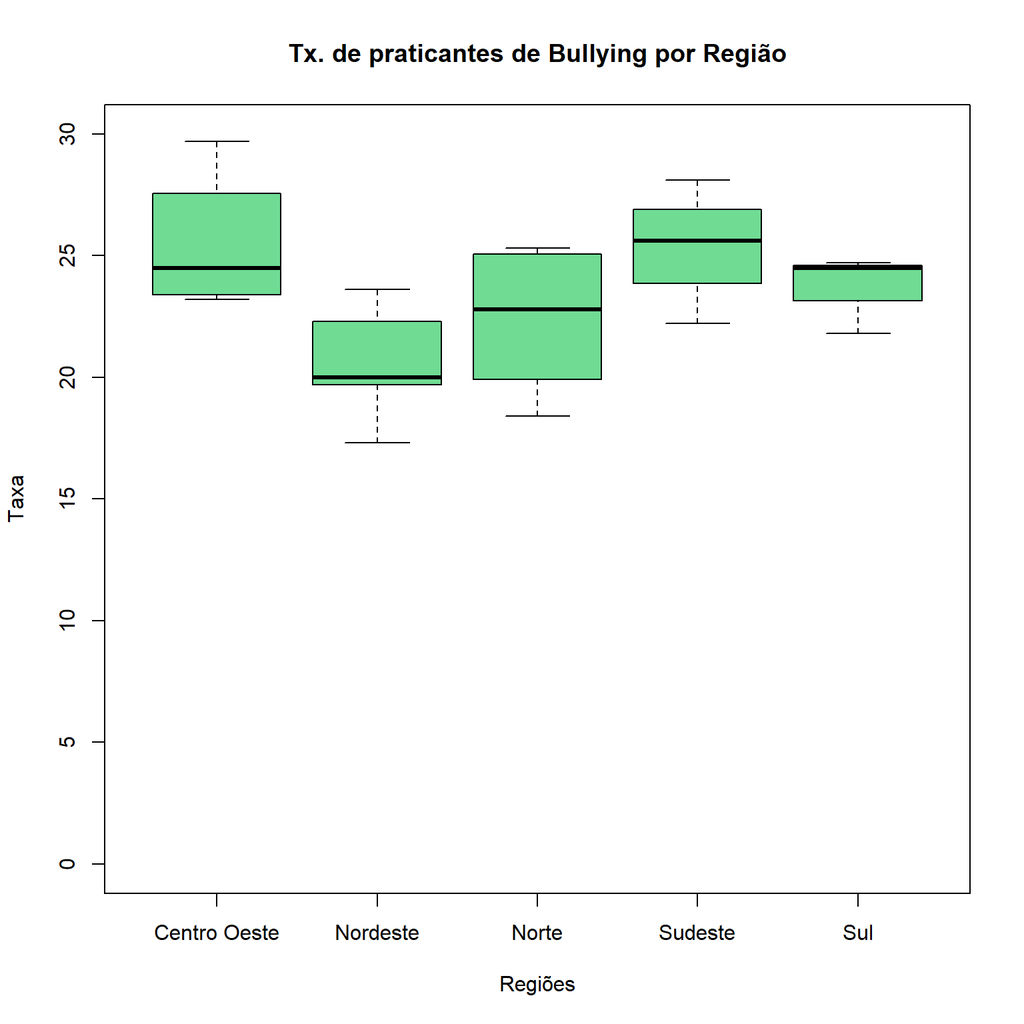

```r
> Boxplot(Bullying~Regiao, data=final, id.method="y", xlab="Regiões", ylab="Taxa",
+   ylim=c(0,30),col=c("#70DB93"),
+   main="Tx. de praticantes de Bullying por Região")
```

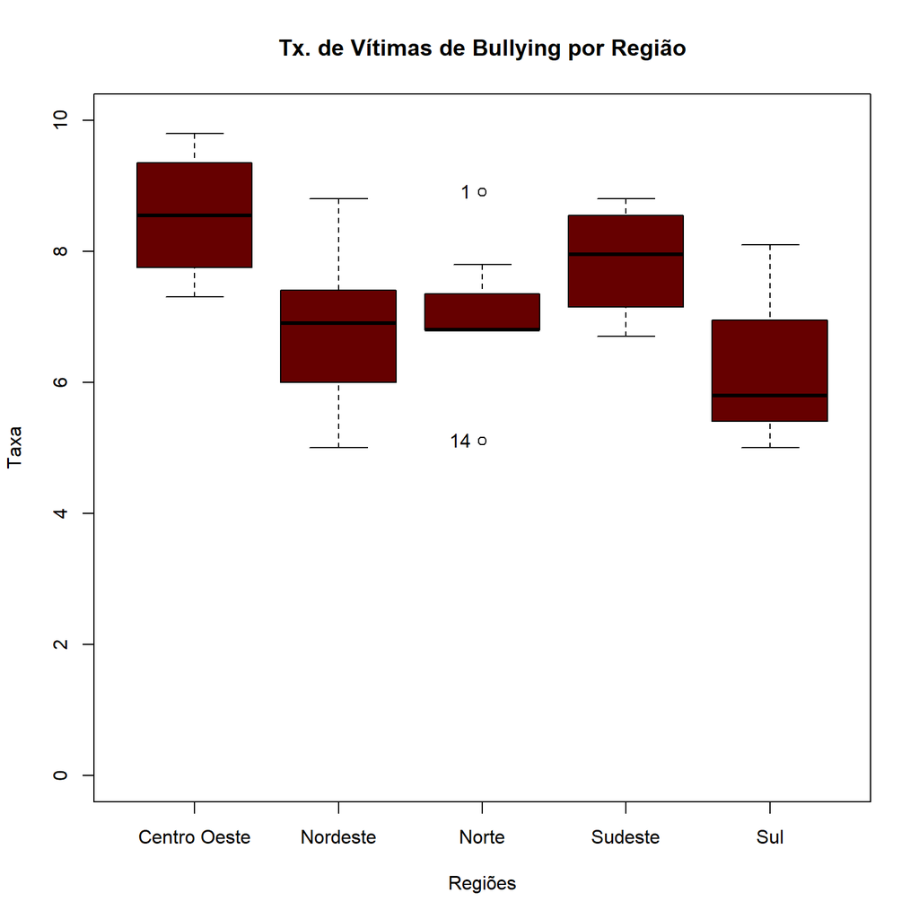

```
[1] "14" "1"
```

```r
> Boxplot(Bullying.Vit~Regiao, data=final, id.method="y", xlab="Regiões", ylab="Taxa",
+   ylim=c(0,10),col=c("#660000"),
+   main="Tx. de Vítimas de Bullying por Região")
```

#### A taxa de crimes violentos letais intencionais se destaca na região Nordeste, tendo predominância dos dados no mais alto patamar (entre 75% e 100% dos dados), conferindo certa proporção nos dados entre todas as regiões.

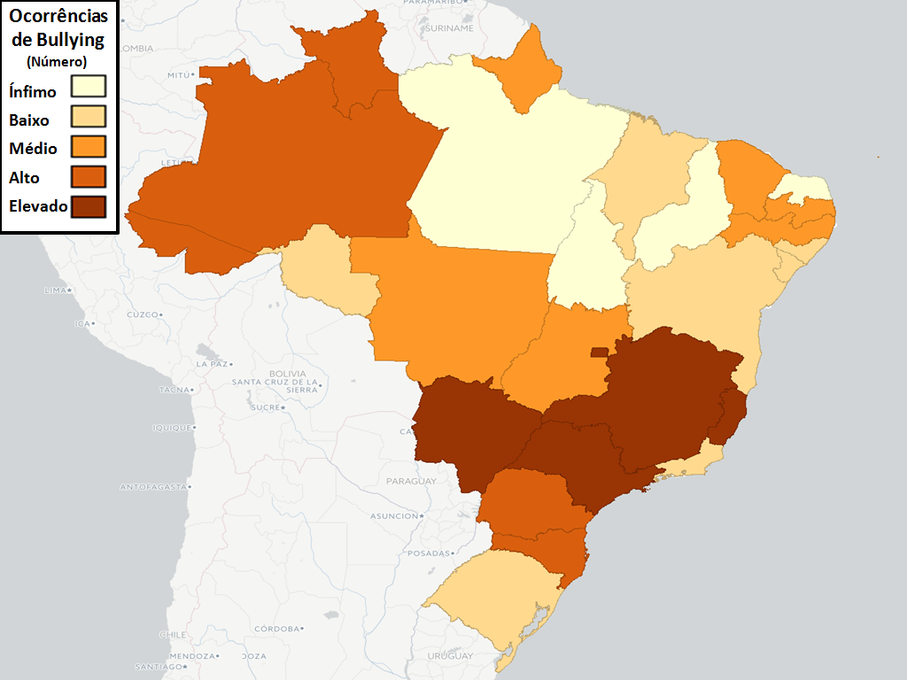

### 4.1 TESTES DE HIPÓTESES

```r
> library(nortest, pos=15)
```

#### - Violência entre as regiões

#### Histograma para verificação visual sobre o tipo de distribuição.

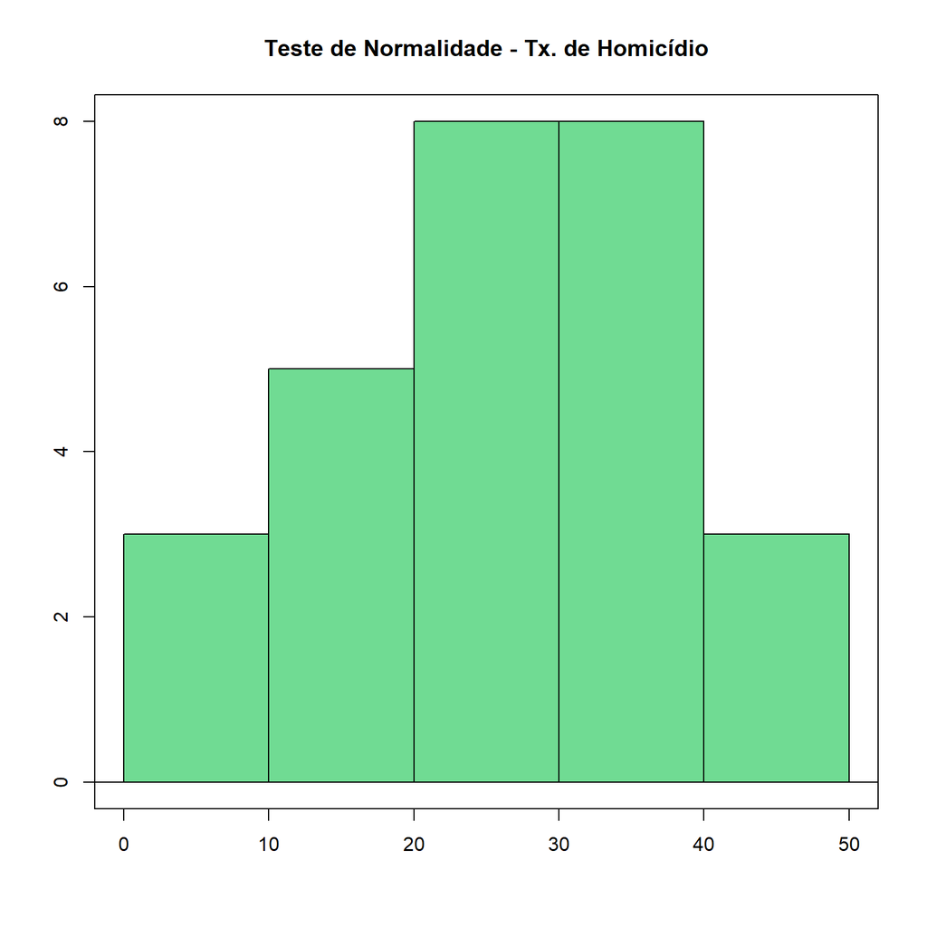

```r
> with(final, Hist(Tx_Hom, scale="frequency", breaks="Sturges", col="#70DB93",
+   xlab="", ylab="", main="Teste de Normalidade - Tx. de Homicídio"))
```

#### Teste de Normalidade

```r
> with(final, shapiro.test(Tx_Hom))
```

```
    Shapiro-Wilk normality test

data:  Tx_Hom
W = 0.96875, p-value = 0.5691
```

#### A distribuição da Taxa de Homicídio é normal.

```r
> library(mvtnorm, pos=16)
```

```r
> library(survival, pos=16)
```

```r
> library(MASS, pos=16)
```

```r
> library(TH.data, pos=16)
> library(multcomp, pos=16)
> library(abind, pos=21)
```

```r
> AnovaModel.1 <- aov(Tx_Hom ~ Regiao, data=final)
> summary(AnovaModel.1)
```

```
            Df Sum Sq Mean Sq F value Pr(>F)
Regiao       4    860   215.0   1.377  0.274
Residuals   22   3436   156.2
```

```r
> with(final, numSummary(Tx_Hom, groups=Regiao, statistics=c("mean", "sd")))
```

```
                 mean        sd data:n
Centro Oeste 29.56533  9.699072      4
Nordeste     31.99664 14.667187      9
Norte        23.63576 13.019316      7
Sudeste      21.59694 10.821975      4
Sul          14.90930  5.692785      3
```

#### Mediante teste de correlação verifica-se a não rejeição da hipóstese nula, ou seja, a µVARIÁVELnorte = µVARIÁVELnordeste = µVARIÁVELsudeste = µVARIÁVELsul = µVARIÁVELnorte = µVARIÁVELcentro oeste.

#### - Relação entre a taxa de praticantes de Bullying com taxa de Homicídios

#### - Teste de normalidade

```r
> with(final, shapiro.test(Bullying))
```

```
    Shapiro-Wilk normality test

data:  Bullying
W = 0.97548, p-value = 0.7493
```

#### A distribuição da Taxa de Bullying é normal, assim como foi visto anteriormente sobre a Taxa de Homicídio.

```r
> with(final, cor.test(Bullying, Tx_Hom, alternative="two.sided", method="pearson"))
```

```
    Pearson's product-moment correlation

data:  Bullying and Tx_Hom
t = -1.3606, df = 25, p-value = 0.1858
alternative hypothesis: true correlation is not equal to 0
95 percent confidence interval:
 -0.5842867  0.1304573
sample estimates:
       cor
-0.2625739
```

#### Mediante teste de correlação, verifica-se a não rejeição da hipóstese nula, ou seja, não há correlação entre as taxas praticantes de Bullying e a de Homicídio.

#### - Relação entre a taxa de praticantes de Bullying com taxa de Latrocínios

#### Teste de Normalidade

```r
> with(final, shapiro.test(Tx_Lat))
```

```
    Shapiro-Wilk normality test

data:  Tx_Lat
W = 0.95558, p-value = 0.2918
```

#### Observa-se que as duas taxas tem distribuição normal.

```r
> with(final, cor.test(Bullying, Tx_Lat, alternative="two.sided", method="pearson"))
```

```
    Pearson's product-moment correlation

data:  Bullying and Tx_Lat
t = -0.83639, df = 25, p-value = 0.4109
alternative hypothesis: true correlation is not equal to 0
95 percent confidence interval:
 -0.5128461  0.2294114
sample estimates:
      cor
-0.164986
```

#### Vê-se a não rejeição da hipótese nula, portanto não existe dependência entre as variáveis.

#### - Relação entre a taxa de praticantes de Bullying com a taxa de Lesão

#### Teste de Normalidade

```r
> with(final, shapiro.test(Tx_Lesao))
```

```
    Shapiro-Wilk normality test

data:  Tx_Lesao
W = 0.48744, p-value = 1.258e-08
```

#### Desta feita, nota-se rejeição da hipótese nula da parte da Taxa de Lesão, logo os dados não seguem uma distribuição normal, que diferentemente é o tipo de distribuição da Taxa de Bullying.

```r
> with(final, cor.test(Bullying, Tx_Lesao, alternative="two.sided",
+   method="spearman"))
```

```
    Spearman's rank correlation rho

data:  Bullying and Tx_Lesao
S = 3690.2, p-value = 0.5297
alternative hypothesis: true rho is not equal to 0
sample estimates:
       rho
-0.1264315
```

#### - Relação entre a Taxa de praticantes de Bullying e a Taxa de Crimes Violentos

#### Teste de Normalidade

```r
> with(final, shapiro.test(Tx_Cv))
```

```
    Shapiro-Wilk normality test

data:  Tx_Cv
W = 0.97532, p-value = 0.7451
```

#### Tem-se a informação a partir do teste de que as duas taxas possuem distribuição normal.

```r
> with(final, cor.test(Bullying, Tx_Cv, alternative="two.sided", method="pearson"))
```

```
    Pearson's product-moment correlation

data:  Bullying and Tx_Cv
t = -2.4215, df = 25, p-value = 0.02304
alternative hypothesis: true correlation is not equal to 0
95 percent confidence interval:
 -0.69994869 -0.06694769
sample estimates:
       cor
-0.4358726
```

#### Constata-se que é rejeitada a hipótese nula, sabendo assim que há correlação entre as taxas de praticantes de Bullying e de Crimes Violentos. Entende-se então a existencia de correlação linear entre as duas variáveis.

### 5. Conclusão

#### Constata-se, dessa forma, que, felizmente, nossa hipótese não se concretiza na realidade, logo, mediante os dados, mesmo diante de aumento da violência, o impacto dentro das escolas não é conectado à violência presente na sociedade. Vale ressaltar o apenas um teste de hipótese apontar dependência, apresentando correlação entre crimes violentos e a prática do bullying, o que nos dá o ensejo de não fechar as porta para o assunto, podendo-se pensar em futuras análises com novos dados. Ainda, perante o majoritário dos fatos, por enquanto não é necessária alta inquietude com o status quo, apenas a manutenção do mesmo.

#### Valendo-se do último quadro, seria proveitoso citar Patrícia Nogueira Pröglhöf, mestranda em Administração Pública e Governo pela Fundação Getúlio Vargas, que participou do anuário Brasileiro de Segurança Pública do ano de 2016 (base de nossa análise) nos deixando a seguinte reflexão, que com a qual encerramos:

> Se queremos que o país reduza seus índices de criminalidade e violência devemos, entre tantas medidas necessárias, garantir que a insegurança não prejudique a oferta de educação, o acesso de nossos jovens a ela e a qualidade do aprendizado. Sobretudo, é preciso que para além dos conteúdos curriculares o ambiente escolar seja capaz de ensinar pela prática às nossas crianças e jovens que a paz é possível.

### 6. Fontes e Referências

#### http://www.forumseguranca.org.br/wp-content/uploads/2017/01/Anuario_Site_27-01-2017-RETIFICADO.pdf

#### https://ww2.ibge.gov.br/home/geociencias/areaterritorial/principal.shtm

#### http://www.ipea.gov.br/portal/